# Documentation Dog Owners Survey

Sandra Tobon

31/03/2020

# 1 Dog Owners Survey

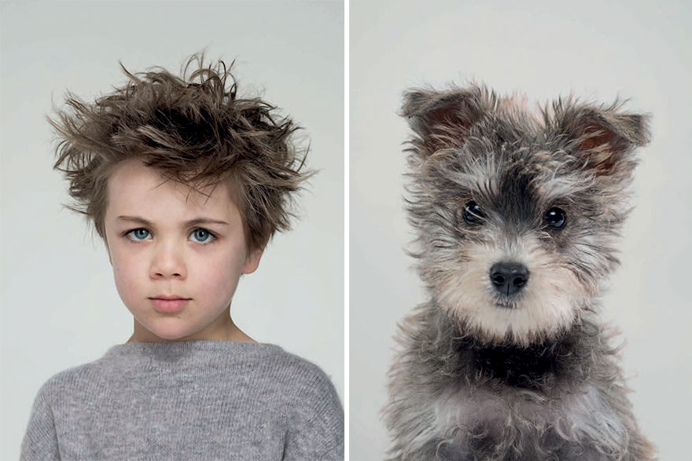

## 1.1 Explanation of the Data Set

This is a “free-hand” survey filled by dog owners. In this survey the owners of the dog answer:

- tittle, first_name, last_name, email
- amount_spent_on_dog_food, dog_size, dog_gender, dog_age

## 1.2 Clean Data Process

The raw_data have a dimensions of 308 rows and 11 columns.

- Only one column had the name different to snake style (Title)
- Three rows were duplicates, two one time and one six times, so we have deleted the duplicates
- Two rows had information about more that one dog, so we have add some rows with the information of each dog, in this way we have one row per dog
- We standardize the columns dog_gender, dog_size
- We standardize the columns dog_age and amount_spent_on_dog_food, also we transform them to numeric and convert to positive
- We didn’t delete NA values, because most of the time the others columns have valid values that we can use in the analysis

## 1.3 Answer the questions

1. The client only counts a valid email address as one ending in ‘.com’. How many survey results have a valid email address

```r
dog_survey %>%
  mutate(is_email = str_ends(email, "\\.com")) %>%
  summarise(total_valid_email = sum(is_email))
```

| total_valid_email |
| --- |
| 180 |

2. The average amount spent on dog food for each dog size

```r
dog_survey %>%
  filter(!c(dog_size == "No entry" | is.na(amount_spent_on_dog_food))) %>%
  group_by(dog_size) %>%
  summarise(amount_spent_on_dog_food_per_size = round(mean(amount_spent_on_dog_food),2)) %>%
  arrange(desc(amount_spent_on_dog_food_per_size))
```

| dog_size | amount_spent_on_dog_food_per_size |
| --- | --- |
| XS | 57.30 |
| XL | 50.74 |
| L | 50.18 |
| S | 49.18 |
| M | 47.26 |

3. The average age of their dog for owners whose surname starts with a letter in the second half of the alphabet (N onwards)

```r
pattern <- "[N-Z]"
dog_survey %>%
  mutate(is_n_to_z = str_starts(last_name, pattern)) %>%
  filter(is_n_to_z == TRUE) %>%
  summarise(average_dog_age_n_to_z = round(mean(dog_age),0))
```

| average_dog_age_n_to_z |
| --- |
| 53 |

4. The dog_age column is the age in dog years. If the conversion is 1 human year = 6 dog years, then what is the average human age for dogs of each gender?

```r
dog_survey %>%
  filter(dog_gender != "No entry") %>%
  mutate(human_age_dog = dog_age/6) %>%
  group_by(dog_gender) %>%
  summarise(average_human_age = round(mean(human_age_dog),0))
```

| dog_gender | average_human_age |
| --- | --- |
| F | 8 |
| M | 8 |
| Unknown | 7 |

5. Create a plot of results of question 4

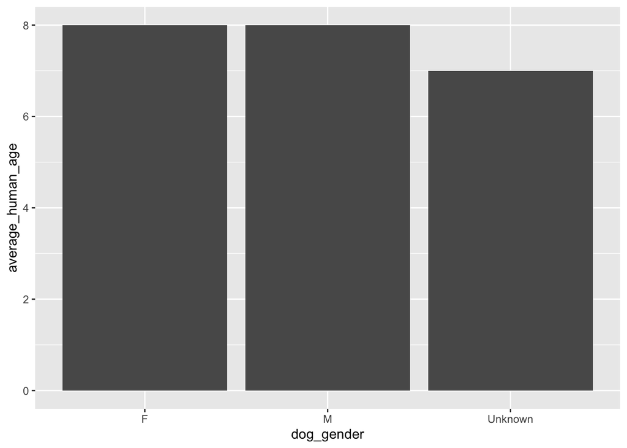

```r
dog_survey %>%
  filter(dog_gender != "No entry") %>%
  mutate(human_age_dog = dog_age/6) %>%
  group_by(dog_gender) %>%
  summarise(average_human_age = round(mean(human_age_dog),0)) %>%
  ggplot(mapping = aes(x = dog_gender, y = average_human_age)) +
  geom_histogram(stat = "identity")
```